# w3-01-Statistical Models Exercises #1

Knut Behrends

January 2, 2016

### Statistical Models Exercises #1 (1 point possible)

Suppose you have an urn with blue and red balls. If N balls at selected at random with replacement (you put the ball back after you pick it) we can denote the outcomes as random variables X1,…,XN that are 1 or 0. If the proportion of red balls is p then the distribution of each of these is:

`Pr(Xi=1) = p.`

These are also called Bernoulli trials. Note that these random variables are independent because we replace the balls. Flipping a coin is an example of this with p=0.5.

You can show that the mean and variance are p and p(1−p) respectively. The binomial distribution gives us the distribution of the sum SN of these random variables. The probability that we see k red balls is given by:

`Pr(SN=k)=(Nk)pk(1−p)N−k`

In R the function `dbinom` gives you this result. The function pbinom gives us `Pr(SN≤k)`.

This equation has many uses in the life sciences. We give some examples below.

The probability of conceiving a girl is 0.49. What is the probability that a family with 4 children has 2 girls and 2 boys (you can assume no twins)?

```r
N <- 4 # trials
k <- 2 # hits
p <- 0.49 #probability

dbinom(k, size=N, prob=p)
```

```
## [1] 0.3747
```

Generalized:

Family can have 20 children maximum, and of these can 0..20 girls

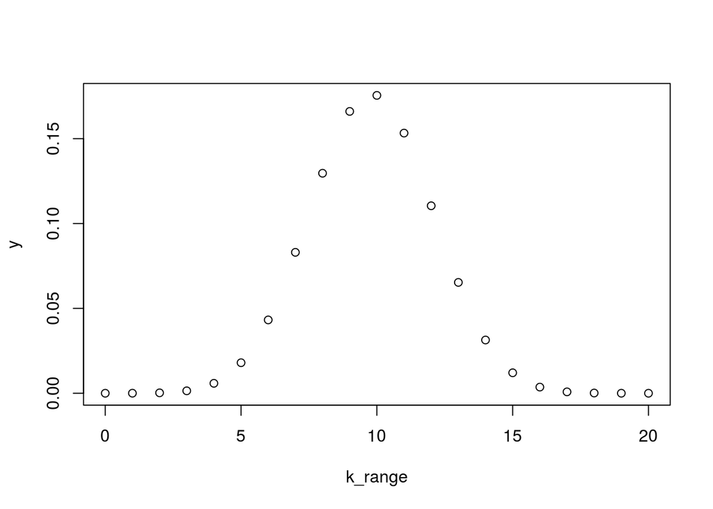

```r
k_range <- seq(0,20,by=1) # 0 to 20 children
N_max <- 20
y <- dbinom(k_range,size=N_max,p)
plot(k_range,y)
```

### Statistical Models Exercises #2 (1 point possible)

Use what you learned in Question #1 to answer these questions:

What is the probability that a family with 10 children has 4 girls and 6 boys (you can assume no twins)?

```r
N <- 10 # trials
k <- 4 # hits
p <- 0.49 #probability

dbinom(k, size=N, prob=p)
```

```
## [1] 0.213
```

### Statistical Models Exercises #3 (1 point possible)

The genome has 3 billion bases. About 20% are C, 20% are G, 30% are T and 30% are A. Suppose you take a random interval of 20 bases, what is the probability that the GC-content (proportion of Gs or Cs) is strictly above 0.5 in this interval (you can assume independence)?

```r
N <- 20 # trials
k <- 10 # hits
p <- (0.2 + 0.2) #probability (G + C)/(G + C + A +T)

pbinom(q=k , size=N, prob=p, lower.tail = FALSE)
```

```
## [1] 0.1275
```

```r
# rafa: 1-pbinom(10,20,0.4)
```

### Statistical Models Exercises #4 (1 point possible)

The following two questions are motivated by this event:

> [Powerball pot soars past $550MILLION as 130,000 tickets are sold a minute in 11th hour frenzy before historic drawing](http://www.dailymail.co.uk/news/article-2239795/Powerball-pot-soars-past-550MILLION-130-000-tickets-sold-minute-11th-hour-frenzy-historic-drawing.html)

The probability of winning the lottery is 1 in 175,223,510. If 189,000,000 randomly generated (with replacement) tickets are sold, what is the probability that at least one winning tickets is sold? (give your answer as a proportion not percentage)

```r
p=1/175223510 ##chances of winning
N=189000000 ## tickets sold
k <- 0 # hits

pbinom(q=k , size=N, prob=p, lower.tail = FALSE)
```

```
## [1] 0.6599
```

### Statistical Models Exercises #5 (1 point possible)

Using the information from the previous question, what is the probability that two or more winning tickets are sold?

```r
p=1/175223510 ##chances of winning
N=189000000 ## tickets sold
k <- 1 # hits

pbinom(q=k , size=N, prob=p, lower.tail = FALSE)
```

```
## [1] 0.2931
```

### Statistical Models Exercises #6 (Normal approximation) (1 point possible)

We can show that the binomial distribution is approximately normal with N is large and p is not too close to 0 or 1. This means that for the distribution of the sum SN of random variables

`SN − E(SN)/ sqrt(Var(SN))`

is approximately normal with mean 0 and SD 1.

Using the results for sums of independent random variables we learned in a previous course, we can show that `E(SN) = N * p` and `Var(Sn) = N * p * (1 − p)`.

The genome has 3 billion bases. About 20% are C, 20% are G, 30% are T and 30% are A. Suppose you take a random interval of 20 bases, what is the exact probability that the GC-content (proportion of Gs of Cs) is greater than 0.35 and smaller or equal to 0.45 in this interval?

```r
N <- 20 # trials
k1 <- 0.35 * N # hits
k2 <- 0.45 * N # hits
p <- 0.4 #probability (G + C)/(G + C + A +T)



p1 <- pbinom(q=k1, size=N, prob=p, lower.tail = TRUE)
p2 <- pbinom(q=k2, size=N, prob=p, lower.tail = FALSE)

p_intv <- 1 - p1 - p2

#rafa:pbinom(9,20,0.4)-pbinom(7,20,0.4)
```

[output not shown]

### Statistical Models Exercises #7 (1 point possible)

For the question above, what is the normal approximation to the probability?

`SN - E(SN)/ sqrt(Var(SN))`

E(SN) = N * p

```r
# rafa:
N <- 20
b <- (9 - N * .4)/sqrt(N*.4*.6)
a <- (7 - N *.4)/sqrt(N*.4*.6)
pnorm(b)-pnorm(a)
```

```
## [1] 0.3519
```

### Statistical Models Exercises #8 (1 point possible)

Repeat question 4.1.3, but using an interval of 1000 bases. What is the difference (in absolute value) between the normal approximation and the exact probability (using binomial) of the GC-content being greater than 0.35 and lesser or equal to 0.45?

```r
N <- 1000

b <- (0.45*N - N * .4)/sqrt(N*.4*.6)
a <- (0.35*N - N *.4)/sqrt(N*.4*.6)
(p_intv_norm <- pnorm(b)-pnorm(a))
```

```
## [1] 0.9988
```

```r
p_intv_binom <- pbinom(0.45*N,N,0.4)-pbinom(0.35*N,N,0.4)
abs(p_intv_binom - p_intv_norm)
```

```
## [1] 9.729e-06
```

```r
# rafa:
# exact = pbinom(450,1000,0.4)-pbinom(350,1000,0.4)
# b <- (450 - 1000*.4)/sqrt(1000*.4*.6)
# a <- (350 - 1000*.4)/sqrt(1000*.4*.6)
# approx <- pnorm(b)-pnorm(a)
# abs(exact-approx)
# = 9.729e-06
```

### Statistical Models Exercises #9 (1 point possible)

The Cs in our genomes can be [*methylated*](http://en.wikipedia.org/wiki/DNA_methylation) or unmethylated. Suppose we have a large (millions) group of cells in which a proportion p of a C of interest are methylated. We break up the DNA of these cells and randomly select pieces and end up with N pieces that contain the C we care about.

This means that the probability of seeing k methylated Cs is binomial:

```r
exact = dbinom(k,N,p)
```

We can approximate this with the normal distribution:

```r
a <- (k+0.5 - N*p)/sqrt(N*p*(1-p))
b <- (k-0.5 - N*p)/sqrt(N*p*(1-p))
approx = pnorm(a) - pnorm(b)
```

Let

```r
#exact = dbinom(k,N,p)
Ns <- c(5,10,30,100)
ps <- c(0.01,0.10,0.5,0.9,0.99)
```

Compare the normal approximation and exact probability (from binomial) of the proportion of Cs being k=1,…,N−1. Plot the exact versus approximate probability for each p- and N- combination.

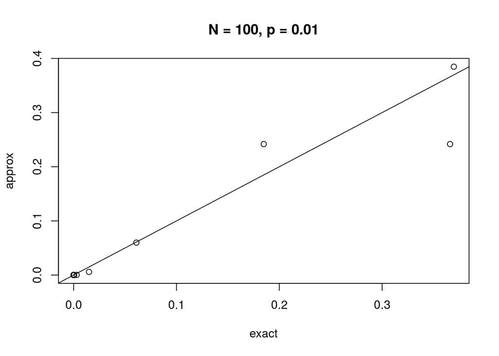

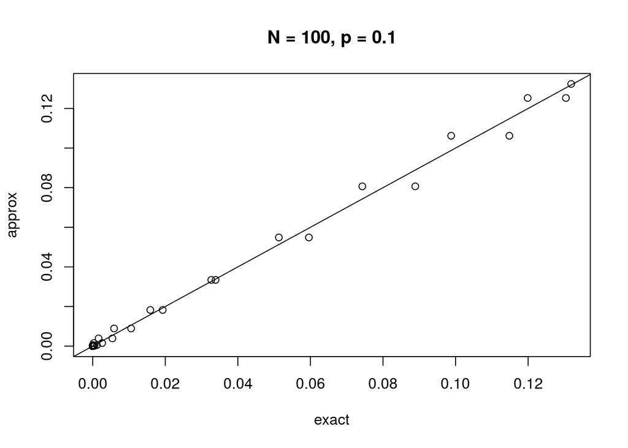

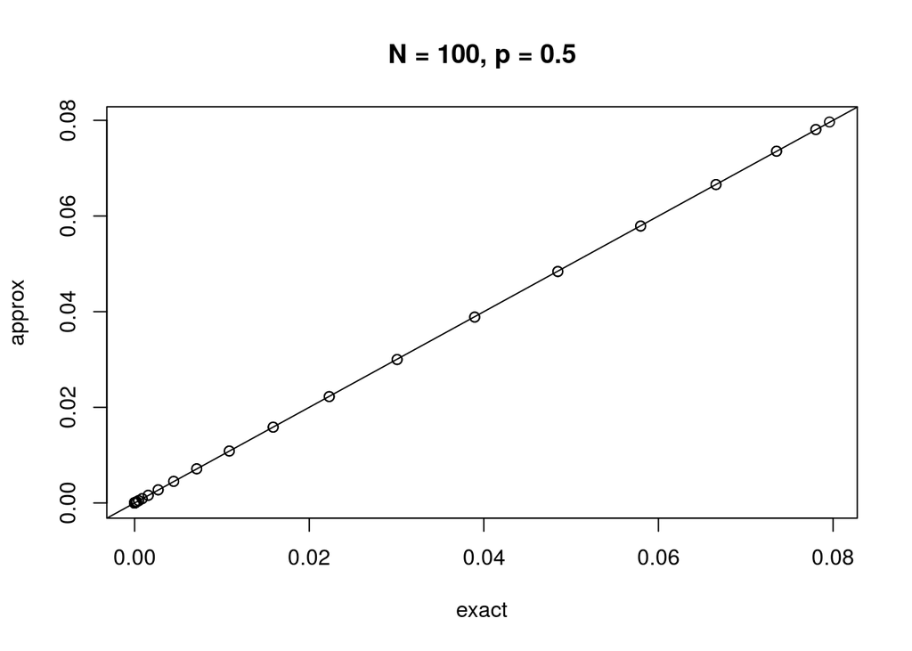

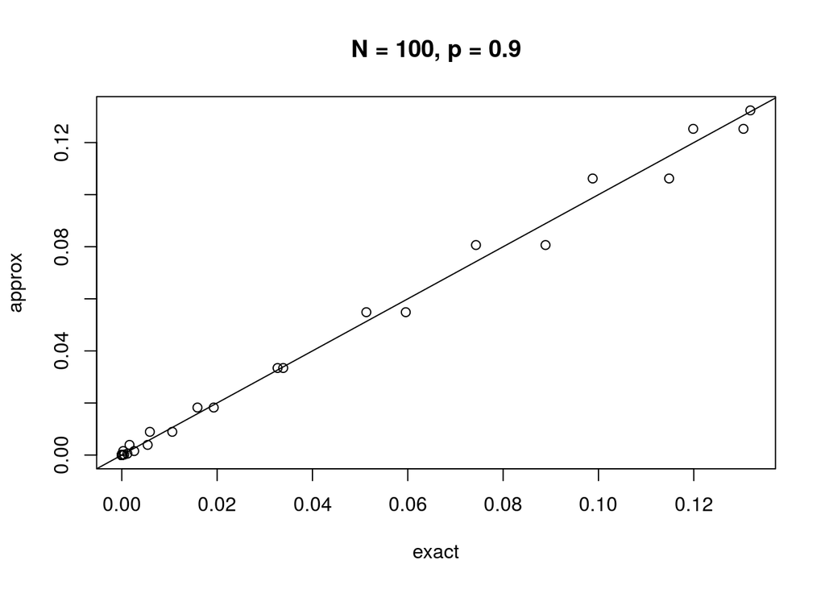

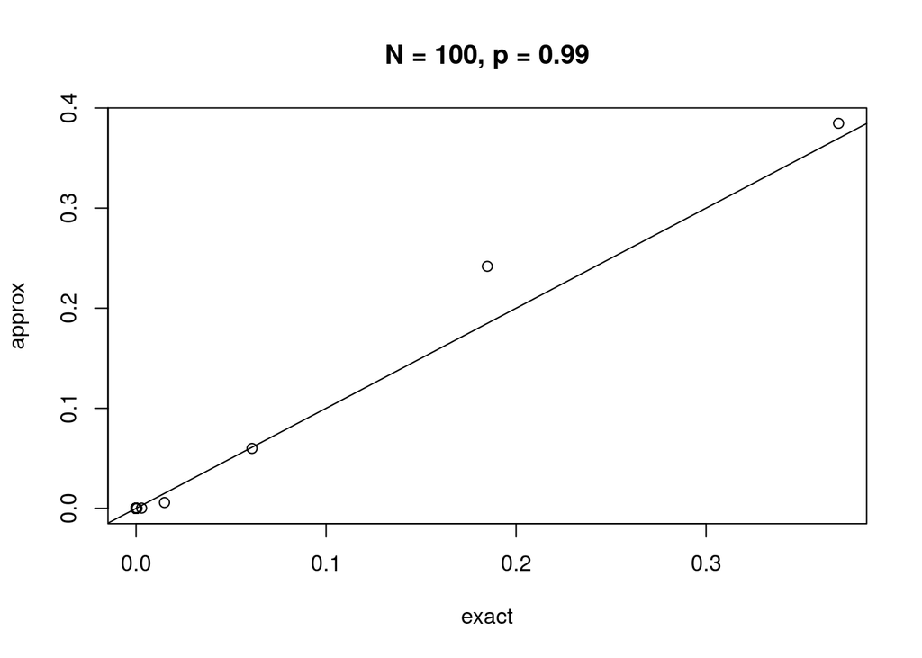

```r
approx <- function(k, N, p){
        a <- (k+0.5 - N*p)/sqrt(N*p*(1-p))
        b <- (k-0.5 - N*p)/sqrt(N*p*(1-p))
        return(abs(pnorm(b)-pnorm(a)))

}

npcomb <- expand.grid(N=Ns, p=ps)
for (i in 1:nrow(npcomb)){
        N <- npcomb[i,"N"]
        p <- npcomb[i,"p"]
        (exact <- dbinom(1:N-1, N, p))
        appr <- sapply(1:N-1, function(x){approx(x, N,p)})
        if(N == 100) {
                plot(exact, appr, xlab="exact", ylab="approx", main = paste0("N = ", N, ", p = ", p))
                abline(0,1)
        }
}
```

Study the plots and tell us which of the following is NOT true:

- The normal approximation works well when p is close to 0.5 even for small N=10.
- The normal approximation breaks down when p is close to 0 or 1 even for large N.
- When N is 100 all approximations are spot on.
- When p=0.01 the approximation are terrible for N=5,10,30 and only OK for N=100.

```r
#rafa's solution:
Ns <- c(5,10,30,100)
ps <- c(0.01,0.10,0.5,0.9,0.99)
library(rafalib)
mypar2(4,5)
for(N in Ns){
  ks <- 1:(N-1)
  for(p in ps){
    exact = dbinom(ks,N,p)
    a = (ks+0.5 - N*p)/sqrt(N*p*(1-p))
    b = (ks-0.5 - N*p)/sqrt(N*p*(1-p))
    approx = pnorm(a) - pnorm(b)
    LIM <- range(c(approx,exact))
    plot(exact,approx,main=paste("N =",N," p = ",p),xlim=LIM,ylim=LIM,col=1,pch=16)
    abline(0,1)
  }
}
```

### Statistical Models Exercises #10 (Poisson approximation) (1 point possible)

We saw in the previous question that when p is very small, the normal approximation breaks down. If N is very large, then we can use the Poisson approximation.

Earlier we computed the probability of 2 or more tickets winning the lottery when the odds of winning were 1 in 175,223,510 and 189,000,000 tickets were sold. Using the binomial we can run the code below to compute the probability of exactly two people winning to be:

```r
N <- 189000000
p <- 1/175223510
dbinom(2,N,p)
```

```
## [1] 0.1978
```

If we were to use the normal approximation, we would overestimate this as you can see by running this code:

```r
a <- (2+0.5 - N*p)/sqrt(N*p*(1-p))
b <- (2-0.5 - N*p)/sqrt(N*p*(1-p))
pnorm(a) - pnorm(b)
```

```
## [1] 0.2569
```

To use the Poisson approximation here use the rate `λ=Np` representing the number of tickets per 189,000,000 that win the lottery. Run the following code and note how much better the approximation is:

```r
1-sum(dpois(0:1,N*p))
```

```
## [1] 0.2931
```

In this case it is practically the same because N is very very large and Np is not 0. These are the assumptions needed for the Poisson to work.

What is the Poisson approximation for the probability of two or more person winning?